**環境資料科學 期末報告**

# 自動區分地震波形中的 P 波與 S 波

**林芳伃 汪其璇 黎昕雯**

## 摘要

本次專題，我們希望利用STA/LTA 方法，挑選可能的地震事件(P、S波的到時)。 訓練MLP (Multi-Layer Perceptron)，用於自動區分地震波形中的 P 波與 S 波，來實現自動挑波。

# 正文

## 原始目標

最初我們原本想透過使用現有的深度學習模型（如 PhaseNet-DAS 等），自動偵測並標記 DAS 數據中的 P 波和 S 波到達時間，以提升地震監測的效率，以利於地震定位，來了解臺北盆地西側的地質。期望可與中央氣象局的地震資料（2019.10 以後資料缺少規模2以下的地震事件）進行比對，期望能從DAS資料中找出中央氣象局有列出來的大地震事件以及規模較小的區域性地震。最後，可以利用cluster 或 K-mean 等工具來了解地震分群與該區域地質之間的關聯(如 Mildon et al.(2022) 和 Sun et al.(2024))。

## 修改目標

但為更好的實現與環境資料處理課堂中的連結，我們自己去訓練模型，來實現自動挑波。接著受限於DAS 數據缺少已挑選的P、S波到時資料，我們改地震儀而非DAS做為資料屬裡的數據。有由於原先設定的目標北台灣西側(位於臺北盆地與林口台地間)，缺少區域性地震事件，我們決定使用20180206位於台灣東側花蓮規模6.26的地震事件及其前震與餘震事件，對模型進行訓練。

[figure not shown]

**圖 1:** 20180206花蓮地震事件地震報告。(交通部中央氣象局地震測報中心提供)

## 資料蒐集

我們首先由自身所在的研究室(已獲導師同意)的數據調該次地震事件當天人工挑選的P、S波到時、偵測到地震的測站、地震事件發震時間，接著由中央氣象署下載偵測到地震事件測站的20180206整日的地震波，並依照測站區分為訓練集 ("HWA", "EHP", "ENA", "ESL")、測試集("ETM")。

[figure not shown]

**圖 2:** 可獲得的地震事件分布、測站分布。藍色三角形為訓練集、紅色三角形為測試集、圓圈為地震事件。

## 結果

**表 1:** 成效

[output not shown]

可以得知模型能夠區分 P 波與 S 波，但分類準確率約為 65%-71%，表現尚可但仍有改進空間，以下為觀察到的現象。

b.損失值：驗證損失（0.8）高於訓練損失（0.5），表明模型可能存在一定過擬合現象。

[figure not shown]

**圖 3:** Feature Importance

[figure not shown]

**圖 4:** Prediction Distribution

預測概率集中在中低範圍，可能表明模型對大多數數據的預測不夠自信。

## 討論

### 數據

a.擴充訓練與驗證數據集，增加 P 波與 S 波的標籤數量，並確保數據分布均衡，特別是在稀有波形事件的標注上。

b.新增非地震事件之波形資料與標籤，訓練模型挑波能力。

### 模型

a.引入更具表現力的模型架構（如 CNN、LSTM），進一步捕捉波形的時序特徵與非線性關係。

b.使用正則化（如 Dropout 或 L2 正則化）來降低過擬合現象，提升泛化能力。

### 其他Features

探索新的時域與頻域Features（如小波變換、頻譜特徵）來進一步增強模型表現。

### 結論

模型在地震波形分類中的初步表現具備一定實用價值，但在準確性與穩定性方面仍需進一步優化。未來可考慮改進特徵提取方法、平衡數據分布或引入更為複雜的模型架構（如深度學習），以提升對 P 波與 S 波的判別能力。同時，需加強正則化技術以緩解過擬合現象，進一步提升模型的泛化能力，從而實現更精確的地震監測效能。

## 方法

```python
!pip3 install obspy
```

資料處理

```python
# version1
# discriminate P and S
import os
import glob
import numpy as np
import pandas as pd
from obspy import read
from obspy.io.sac import attach_paz
from obspy.signal.trigger import classic_sta_lta
from obspy.signal.filter import envelope
from obspy import UTCDateTime
from sklearn.preprocessing import StandardScaler
from sklearn.model_selection import train_test_split
from tensorflow.keras.layers import Dropout
from tensorflow.keras.models import Sequential
from tensorflow.keras.layers import Dense
from tensorflow.keras.optimizers import Adam
from sklearn.metrics import accuracy_score
import matplotlib.pyplot as plt
from datetime import datetime, timedelta
from obspy.core.trace import Trace

Trace._max_processing_info = 200
# 定義測站與日期
train_sta = ["HWA", "EHP", "ENA", "ESL"]
test_sta = ["ETM"]
comp = ["HLN", "HLE", "HLZ"]
train_date = ["20180206"]
test_date = ["20180206"]

# 將 YYYYMMDD 轉為儒略日
def date_to_doy(date_str):
    date = datetime.strptime(date_str, "%Y%m%d")  # 解析日期格式
    doy = date.timetuple().tm_yday  # 獲取儒略日
    return f"{date.year}.{doy:03d}"  # 格式化為 YYYY.DDD

# 將日期列表轉換為儒略日列表
train_date_doy = [date_to_doy(d) for d in train_date]
test_date_doy = [date_to_doy(d) for d in test_date]

# 輸出結果
print(f"訓練日期（儒略日格式）: {train_date_doy}")
print(f"測試日期（儒略日格式）: {test_date_doy}")

# 根據參數讀取檔案
def load_waveform_files(stations, dates):
    files = []
    for station in stations:
        for date in dates:  # 逐一處理每個儒略日期
            files.extend(
                [f for f in os.listdir() if f.startswith(f"TW.{station}") and date in f]
            )
    return files

# 加載訓練與測試檔案
train_files = load_waveform_files(train_sta, train_date_doy)
test_files = load_waveform_files(test_sta, test_date_doy)

# 輸出結果
print(f"訓練檔案數量: {len(train_files)}")
print(f"測試檔案數量: {len(test_files)}")

# 讀取地震事件資訊
event_info = pd.read_csv("evt_PS_0206", sep='\s+', header=None,
                         names=["event_date","event_time", "lat", "lon", "depth", "mag", "Unknown2", "Unknown3", "Unknown4", "event_id"])

station_info = pd.read_csv("sta_PS_20180206", sep='\s+', header=None,
                           names=["station", "latitude", "longitude", "elevation","count"])

# 讀取地震到時檔案
tt_ps_data = []
with open("tt_PS_20180206", "r") as file:
    current_event_id = None
    for line in file:
        line = line.strip()
        if line.startswith("#"):
            current_event_id = int(line.split()[-1])
        else:
            parts = line.split()
            station, travel_time, weight, phase = parts[0], float(parts[1]), int(parts[2]), parts[3]
            tt_ps_data.append([current_event_id, station, travel_time, weight, phase])

tt_ps_df = pd.DataFrame(tt_ps_data, columns=["event_id", "station", "travel_time", "weight", "phase"])


# 時窗處理：根據波相選擇不同的時間窗
def preprocess_waveform(waveform,PZ):
    waveform.detrend(type="demean")
    waveform.detrend(type="linear")
    waveform.taper(max_percentage=0.05, type="hann")

    nqf=waveform.stats.sampling_rate/2 ###nyquist frequency
    pre_filt = [0.005, 0.008 , nqf-2, nqf] ### zero phase filter band
    ### 把PZ的資料餵給waveform
    attach_paz(waveform,PZ )
    paz = dict(waveform.stats.paz)
    waveform.simulate(paz_remove=paz,pre_filt=pre_filt)
    # waveform.plot()
    waveform.taper(0.05, type='hann')
    waveform.filter("bandpass", freqmin=0.1, freqmax=20.0)
    return waveform

# 特徵提取函數
def extract_features(waveform):#, phase):
    data = waveform.data
    env = envelope(data)
    sta_lta = classic_sta_lta(data, int(0.1 * waveform.stats.sampling_rate), int(1 * waveform.stats.sampling_rate))

    features = [
        np.max(env), np.mean(env), np.std(env),
        np.max(sta_lta), np.mean(sta_lta),
    ]
    return features

def extract_data_with_station_time(files, selected_phases, event_info, tt_ps_df):
    X, y = [], []
    for file in files:
        st = read(file)

        for tr in st:
            station = tr.stats.station
            comp = tr.stats.channel
            starttime = tr.stats.starttime
            endtime = tr.stats.endtime

            PZ_pattern = f"SAC_PZs_TW_{station}_{comp}_*"
            PZ = glob.glob(PZ_pattern)[0]

            tr_processed = preprocess_waveform(tr,PZ)

            for event_id in event_info["event_id"]:
                event_date = event_info[event_info["event_id"] == event_id]["event_date"].values[0]
                event_time = event_info[event_info["event_id"] == event_id]["event_time"].values[0]
                event_mag = event_info[event_info["event_id"] == event_id]["mag"].values[0]
                # event_lon = event_info[event_info["event_id"] == event_id]["lon"].values[0]
                # event_lat = event_info[event_info["event_id"] == event_id]["lat"].values[0]

                event_time_str = f"{event_date}{str(event_time).zfill(8)[:6]}"
                event_time_dt = datetime.strptime(event_time_str, "%Y%m%d%H%M%S")
                event_timestamp = event_time_dt.timestamp()

                if not (starttime.timestamp <= event_timestamp <= endtime.timestamp):
                    continue
                # 不是每個地震事件都能被測站偵測到!
                matching_rows = tt_ps_df[
                    (tt_ps_df["station"] == station) &
                    (tt_ps_df["phase"].isin(selected_phases)) &
                    (tt_ps_df["event_id"] == event_id)
                ]

                # sta_lon = station_info[station_info["station"] == station]["longitude"].values[0]
                # sta_lat = station_info[station_info["station"] == station]["latitude"].values[0]

                if matching_rows.empty:
                    continue
                else: # 如果事件被測站偵測到再進行處理
                  start_time = event_time_dt - timedelta(seconds=10)
                  end_time = event_time_dt + timedelta(seconds=120)

                  P_arrival = matching_rows[matching_rows["phase"] == "P"].iloc[0]["travel_time"]
                  S_arrival = matching_rows[matching_rows["phase"] == "S"].iloc[0]["travel_time"]

                  try:
                      # 根據波相進行時間窗截取，再進行前處理
                      tr_processed_evt = tr_processed.copy()
                      tr_processed_evt.trim(starttime=UTCDateTime(start_time), endtime=UTCDateTime(end_time))
                      # print(f"event")
                      # tr_processed_evt.plot()

                      for phase in selected_phases:
                          if phase == "P":
                            # trim tr_processed from P_arrival to P_arrival+5
                            tr_trimmed = tr_processed_evt.trim( 10+P_arrival, 10+P_arrival+5)
                            # print(f"P")
                            # tr_trimmed.plot()
                            features = extract_features(tr_trimmed) # , phase)
                            phase_label = 0

                          else:
                            # trim tr_processed from S_arrival to S_arrival+15
                            tr_trimmed = tr_processed_evt.trim(10+S_arrival, 10+S_arrival+15)
                            # tr_trimmed.plot()

                            features = extract_features(tr_trimmed) # , phase)
                            phase_label = 1

                          X.append(features,event_mag)
                          y.append(phase_label)
                  except Exception as e:
                      print(f"波形處理失敗: {e}")
                      continue
    return np.array(X), np.array(y)

# 提取數據與標籤
selected_phases = ["P", "S"]

X_train, y_train = extract_data_with_station_time(train_files, selected_phases, event_info, tt_ps_df)
X_test, y_test = extract_data_with_station_time(test_files, selected_phases, event_info, tt_ps_df)
```

模型測試

```python
# 最初模型設置
# 訓練分類模型
model = Sequential([
    Dense(64, input_dim=X_train.shape[1], activation='relu'),
    Dense(64, activation='relu'),
    Dense(1, activation='sigmoid')  # 用 sigmoid 來做二分類
])
## 訓練模型
# 編譯模型
model.compile(optimizer=Adam(), loss='binary_crossentropy', metrics=['accuracy'])
# 訓練過程
model.fit(X_train, y_train, epochs=100, batch_size=32, validation_data=(X_test, y_test))

# 測試模型
y_pred = model.predict(X_test)
y_pred_label = (y_pred > 0.5).astype(int)

# 計算準確率
accuracy = accuracy_score(y_test, y_pred_label)
print(f"Accuracy: {accuracy * 100:.2f}%")
```

```
93/93 ━━━━━━━━━━━━━━━━━━━━ 2s 5ms/step - accuracy: 0.6356 - loss: 0.6607 - val_accuracy: 0.6383 - val_loss: 0.6501
93/93 ━━━━━━━━━━━━━━━━━━━━ 0s 3ms/step - accuracy: 0.6528 - loss: 0.6310 - val_accuracy: 0.6402 - val_loss: 0.6563
93/93 ━━━━━━━━━━━━━━━━━━━━ 1s 3ms/step - accuracy: 0.6643 - loss: 0.6222 - val_accuracy: 0.6480 - val_loss: 0.6377
93/93 ━━━━━━━━━━━━━━━━━━━━ 0s 3ms/step - accuracy: 0.6688 - loss: 0.6106 - val_accuracy: 0.6511 - val_loss: 0.6392
93/93 ━━━━━━━━━━━━━━━━━━━━ 1s 3ms/step - accuracy: 0.6740 - loss: 0.6012 - val_accuracy: 0.6542 - val_loss: 0.6368
93/93 ━━━━━━━━━━━━━━━━━━━━ 1s 4ms/step - accuracy: 0.6862 - loss: 0.5981 - val_accuracy: 0.6507 - val_loss: 0.6386
93/93 ━━━━━━━━━━━━━━━━━━━━ 1s 3ms/step - accuracy: 0.6765 - loss: 0.5978 - val_accuracy: 0.6395 - val_loss: 0.6745
93/93 ━━━━━━━━━━━━━━━━━━━━ 1s 3ms/step - accuracy: 0.6836 - loss: 0.5919 - val_accuracy: 0.6542 - val_loss: 0.6383
93/93 ━━━━━━━━━━━━━━━━━━━━ 0s 3ms/step - accuracy: 0.6849 - loss: 0.5871 - val_accuracy: 0.6500 - val_loss: 0.6732
93/93 ━━━━━━━━━━━━━━━━━━━━ 1s 4ms/step - accuracy: 0.7037 - loss: 0.5805 - val_accuracy: 0.6601 - val_loss: 0.6282
93/93 ━━━━━━━━━━━━━━━━━━━━ 1s 3ms/step - accuracy: 0.6839 - loss: 0.5828 - val_accuracy: 0.6538 - val_loss: 0.6417
93/93 ━━━━━━━━━━━━━━━━━━━━ 0s 3ms/step - accuracy: 0.6885 - loss: 0.5826 - val_accuracy: 0.6480 - val_loss: 0.6659
93/93 ━━━━━━━━━━━━━━━━━━━━ 0s 3ms/step - accuracy: 0.6841 - loss: 0.5855 - val_accuracy: 0.6554 - val_loss: 0.6503
93/93 ━━━━━━━━━━━━━━━━━━━━ 1s 3ms/step - accuracy: 0.6673 - loss: 0.5949 - val_accuracy: 0.6511 - val_loss: 0.6686
93/93 ━━━━━━━━━━━━━━━━━━━━ 1s 3ms/step - accuracy: 0.6725 - loss: 0.5940 - val_accuracy: 0.6461 - val_loss: 0.6965
93/93 ━━━━━━━━━━━━━━━━━━━━ 1s 3ms/step - accuracy: 0.6894 - loss: 0.5773 - val_accuracy: 0.6457 - val_loss: 0.6793
93/93 ━━━━━━━━━━━━━━━━━━━━ 0s 3ms/step - accuracy: 0.7017 - loss: 0.5673 - val_accuracy: 0.6519 - val_loss: 0.6558
93/93 ━━━━━━━━━━━━━━━━━━━━ 1s 4ms/step - accuracy: 0.6649 - loss: 0.5975 - val_accuracy: 0.6515 - val_loss: 0.6689
93/93 ━━━━━━━━━━━━━━━━━━━━ 0s 4ms/step - accuracy: 0.6834 - loss: 0.5783 - val_accuracy: 0.6562 - val_loss: 0.6505
93/93 ━━━━━━━━━━━━━━━━━━━━ 1s 7ms/step - accuracy: 0.6948 - loss: 0.5751 - val_accuracy: 0.6554 - val_loss: 0.6609
93/93 ━━━━━━━━━━━━━━━━━━━━ 1s 7ms/step - accuracy: 0.6917 - loss: 0.5772 - val_accuracy: 0.6581 - val_loss: 0.6674
93/93 ━━━━━━━━━━━━━━━━━━━━ 2s 16ms/step - accuracy: 0.6857 - loss: 0.5712 - val_accuracy: 0.6469 - val_loss: 0.7023
93/93 ━━━━━━━━━━━━━━━━━━━━ 1s 5ms/step - accuracy: 0.7090 - loss: 0.5703 - val_accuracy: 0.6515 - val_loss: 0.6805
93/93 ━━━━━━━━━━━━━━━━━━━━ 1s 5ms/step - accuracy: 0.7085 - loss: 0.5591 - val_accuracy: 0.6538 - val_loss: 0.7031
93/93 ━━━━━━━━━━━━━━━━━━━━ 1s 8ms/step - accuracy: 0.6936 - loss: 0.5764 - val_accuracy: 0.6550 - val_loss: 0.6754
93/93 ━━━━━━━━━━━━━━━━━━━━ 1s 7ms/step - accuracy: 0.6996 - loss: 0.5699 - val_accuracy: 0.6531 - val_loss: 0.6916
93/93 ━━━━━━━━━━━━━━━━━━━━ 1s 4ms/step - accuracy: 0.6722 - loss: 0.5878 - val_accuracy: 0.6461 - val_loss: 0.7069
93/93 ━━━━━━━━━━━━━━━━━━━━ 0s 3ms/step - accuracy: 0.6944 - loss: 0.5743 - val_accuracy: 0.6519 - val_loss: 0.6879
93/93 ━━━━━━━━━━━━━━━━━━━━ 1s 4ms/step - accuracy: 0.6872 - loss: 0.5823 - val_accuracy: 0.6546 - val_loss: 0.6686
93/93 ━━━━━━━━━━━━━━━━━━━━ 1s 4ms/step - accuracy: 0.6847 - loss: 0.5762 - val_accuracy: 0.6503 - val_loss: 0.7299
93/93 ━━━━━━━━━━━━━━━━━━━━ 1s 3ms/step - accuracy: 0.6925 - loss: 0.5827 - val_accuracy: 0.6488 - val_loss: 0.7329
93/93 ━━━━━━━━━━━━━━━━━━━━ 1s 4ms/step - accuracy: 0.7068 - loss: 0.5666 - val_accuracy: 0.6597 - val_loss: 0.6776
93/93 ━━━━━━━━━━━━━━━━━━━━ 1s 4ms/step - accuracy: 0.6832 - loss: 0.5786 - val_accuracy: 0.6511 - val_loss: 0.7331
93/93 ━━━━━━━━━━━━━━━━━━━━ 0s 3ms/step - accuracy: 0.6858 - loss: 0.5793 - val_accuracy: 0.6500 - val_loss: 0.7226
93/93 ━━━━━━━━━━━━━━━━━━━━ 1s 3ms/step - accuracy: 0.7016 - loss: 0.5691 - val_accuracy: 0.6519 - val_loss: 0.6980
93/93 ━━━━━━━━━━━━━━━━━━━━ 1s 4ms/step - accuracy: 0.6806 - loss: 0.5767 - val_accuracy: 0.6620 - val_loss: 0.6919
93/93 ━━━━━━━━━━━━━━━━━━━━ 1s 6ms/step - accuracy: 0.7000 - loss: 0.5701 - val_accuracy: 0.6515 - val_loss: 0.7523
93/93 ━━━━━━━━━━━━━━━━━━━━ 1s 5ms/step - accuracy: 0.6937 - loss: 0.5738 - val_accuracy: 0.6507 - val_loss: 0.7644
93/93 ━━━━━━━━━━━━━━━━━━━━ 1s 5ms/step - accuracy: 0.6877 - loss: 0.5759 - val_accuracy: 0.6507 - val_loss: 0.7546
93/93 ━━━━━━━━━━━━━━━━━━━━ 1s 5ms/step - accuracy: 0.6958 - loss: 0.5750 - val_accuracy: 0.6531 - val_loss: 0.7652
```

[output cut: 47 more lines]

```
93/93 ━━━━━━━━━━━━━━━━━━━━ 0s 3ms/step - accuracy: 0.6993 - loss: 0.5702 - val_accuracy: 0.6546 - val_loss: 0.8098
93/93 ━━━━━━━━━━━━━━━━━━━━ 0s 4ms/step - accuracy: 0.7011 - loss: 0.5648 - val_accuracy: 0.6573 - val_loss: 0.8260
93/93 ━━━━━━━━━━━━━━━━━━━━ 1s 3ms/step - accuracy: 0.7200 - loss: 0.5480 - val_accuracy: 0.6546 - val_loss: 0.8668
93/93 ━━━━━━━━━━━━━━━━━━━━ 1s 4ms/step - accuracy: 0.7000 - loss: 0.5616 - val_accuracy: 0.6573 - val_loss: 0.8459
93/93 ━━━━━━━━━━━━━━━━━━━━ 1s 4ms/step - accuracy: 0.7014 - loss: 0.5619 - val_accuracy: 0.6620 - val_loss: 0.7531
93/93 ━━━━━━━━━━━━━━━━━━━━ 1s 4ms/step - accuracy: 0.6995 - loss: 0.5705 - val_accuracy: 0.6496 - val_loss: 0.8636
93/93 ━━━━━━━━━━━━━━━━━━━━ 1s 4ms/step - accuracy: 0.6965 - loss: 0.5674 - val_accuracy: 0.6480 - val_loss: 0.8936
93/93 ━━━━━━━━━━━━━━━━━━━━ 1s 3ms/step - accuracy: 0.7060 - loss: 0.5553 - val_accuracy: 0.6492 - val_loss: 0.9137
93/93 ━━━━━━━━━━━━━━━━━━━━ 1s 4ms/step - accuracy: 0.7014 - loss: 0.5644 - val_accuracy: 0.6570 - val_loss: 0.7913
93/93 ━━━━━━━━━━━━━━━━━━━━ 0s 4ms/step - accuracy: 0.6970 - loss: 0.5692 - val_accuracy: 0.6507 - val_loss: 0.9175
93/93 ━━━━━━━━━━━━━━━━━━━━ 1s 4ms/step - accuracy: 0.7117 - loss: 0.5467 - val_accuracy: 0.6488 - val_loss: 0.8690
93/93 ━━━━━━━━━━━━━━━━━━━━ 0s 3ms/step - accuracy: 0.7026 - loss: 0.5609 - val_accuracy: 0.6632 - val_loss: 0.8263
93/93 ━━━━━━━━━━━━━━━━━━━━ 1s 3ms/step - accuracy: 0.7043 - loss: 0.5515 - val_accuracy: 0.6562 - val_loss: 0.8127
81/81 ━━━━━━━━━━━━━━━━━━━━ 0s 2ms/step
Accuracy: 65.62%
```

```python
# 改用不同的loss function
# 訓練分類模型
model = Sequential([
    Dense(64, input_dim=X_train.shape[1], activation='relu'),
    Dense(64, activation='relu'),
    Dense(1, activation='sigmoid')  # 用 sigmoid 來做二分類
])
## 訓練模型
# 編譯模型
model.compile(optimizer=Adam(), loss='mean_squared_error', metrics=['accuracy'])
# 訓練過程
model.fit(X_train, y_train, epochs=100, batch_size=32, validation_data=(X_test, y_test))

# 測試模型
y_pred = model.predict(X_test)
y_pred_label = (y_pred > 0.5).astype(int)

# 計算準確率
accuracy = accuracy_score(y_test, y_pred_label)
print(f"Accuracy: {accuracy * 100:.2f}%")
```

```
93/93 ━━━━━━━━━━━━━━━━━━━━ 7s 11ms/step - accuracy: 0.5710 - loss: 0.2411 - val_accuracy: 0.6185 - val_loss: 0.2357
93/93 ━━━━━━━━━━━━━━━━━━━━ 1s 8ms/step - accuracy: 0.6552 - loss: 0.2209 - val_accuracy: 0.6410 - val_loss: 0.2304
93/93 ━━━━━━━━━━━━━━━━━━━━ 1s 8ms/step - accuracy: 0.6699 - loss: 0.2131 - val_accuracy: 0.6461 - val_loss: 0.2241
93/93 ━━━━━━━━━━━━━━━━━━━━ 2s 13ms/step - accuracy: 0.6643 - loss: 0.2138 - val_accuracy: 0.6399 - val_loss: 0.2265
93/93 ━━━━━━━━━━━━━━━━━━━━ 0s 4ms/step - accuracy: 0.6829 - loss: 0.2034 - val_accuracy: 0.6523 - val_loss: 0.2193
93/93 ━━━━━━━━━━━━━━━━━━━━ 1s 4ms/step - accuracy: 0.6747 - loss: 0.2086 - val_accuracy: 0.6542 - val_loss: 0.2266
93/93 ━━━━━━━━━━━━━━━━━━━━ 1s 6ms/step - accuracy: 0.6920 - loss: 0.1990 - val_accuracy: 0.6655 - val_loss: 0.2161
93/93 ━━━━━━━━━━━━━━━━━━━━ 1s 7ms/step - accuracy: 0.6819 - loss: 0.2026 - val_accuracy: 0.6402 - val_loss: 0.2289
93/93 ━━━━━━━━━━━━━━━━━━━━ 1s 7ms/step - accuracy: 0.6838 - loss: 0.2026 - val_accuracy: 0.6523 - val_loss: 0.2253
93/93 ━━━━━━━━━━━━━━━━━━━━ 1s 3ms/step - accuracy: 0.6713 - loss: 0.2098 - val_accuracy: 0.6671 - val_loss: 0.2155
93/93 ━━━━━━━━━━━━━━━━━━━━ 1s 4ms/step - accuracy: 0.7028 - loss: 0.1975 - val_accuracy: 0.6550 - val_loss: 0.2185
93/93 ━━━━━━━━━━━━━━━━━━━━ 1s 3ms/step - accuracy: 0.6824 - loss: 0.2011 - val_accuracy: 0.6550 - val_loss: 0.2203
93/93 ━━━━━━━━━━━━━━━━━━━━ 1s 4ms/step - accuracy: 0.6822 - loss: 0.2044 - val_accuracy: 0.6562 - val_loss: 0.2196
93/93 ━━━━━━━━━━━━━━━━━━━━ 0s 3ms/step - accuracy: 0.6938 - loss: 0.1971 - val_accuracy: 0.6566 - val_loss: 0.2169
93/93 ━━━━━━━━━━━━━━━━━━━━ 1s 4ms/step - accuracy: 0.6754 - loss: 0.2000 - val_accuracy: 0.6585 - val_loss: 0.2212
93/93 ━━━━━━━━━━━━━━━━━━━━ 1s 4ms/step - accuracy: 0.6868 - loss: 0.2003 - val_accuracy: 0.6589 - val_loss: 0.2150
93/93 ━━━━━━━━━━━━━━━━━━━━ 1s 3ms/step - accuracy: 0.6952 - loss: 0.1978 - val_accuracy: 0.6546 - val_loss: 0.2252
93/93 ━━━━━━━━━━━━━━━━━━━━ 1s 4ms/step - accuracy: 0.6932 - loss: 0.1999 - val_accuracy: 0.6535 - val_loss: 0.2290
93/93 ━━━━━━━━━━━━━━━━━━━━ 1s 4ms/step - accuracy: 0.6922 - loss: 0.2005 - val_accuracy: 0.6589 - val_loss: 0.2232
93/93 ━━━━━━━━━━━━━━━━━━━━ 1s 4ms/step - accuracy: 0.6859 - loss: 0.2047 - val_accuracy: 0.6589 - val_loss: 0.2181
93/93 ━━━━━━━━━━━━━━━━━━━━ 1s 4ms/step - accuracy: 0.6862 - loss: 0.2034 - val_accuracy: 0.6577 - val_loss: 0.2189
93/93 ━━━━━━━━━━━━━━━━━━━━ 1s 4ms/step - accuracy: 0.6864 - loss: 0.2002 - val_accuracy: 0.6511 - val_loss: 0.2262
93/93 ━━━━━━━━━━━━━━━━━━━━ 1s 4ms/step - accuracy: 0.6807 - loss: 0.2015 - val_accuracy: 0.6418 - val_loss: 0.2335
93/93 ━━━━━━━━━━━━━━━━━━━━ 1s 4ms/step - accuracy: 0.6832 - loss: 0.2051 - val_accuracy: 0.6570 - val_loss: 0.2203
93/93 ━━━━━━━━━━━━━━━━━━━━ 1s 4ms/step - accuracy: 0.6895 - loss: 0.1970 - val_accuracy: 0.6546 - val_loss: 0.2236
93/93 ━━━━━━━━━━━━━━━━━━━━ 1s 6ms/step - accuracy: 0.7096 - loss: 0.1928 - val_accuracy: 0.6519 - val_loss: 0.2242
93/93 ━━━━━━━━━━━━━━━━━━━━ 1s 6ms/step - accuracy: 0.6967 - loss: 0.1938 - val_accuracy: 0.6566 - val_loss: 0.2165
93/93 ━━━━━━━━━━━━━━━━━━━━ 1s 7ms/step - accuracy: 0.6933 - loss: 0.1991 - val_accuracy: 0.6593 - val_loss: 0.2158
93/93 ━━━━━━━━━━━━━━━━━━━━ 1s 4ms/step - accuracy: 0.6874 - loss: 0.2000 - val_accuracy: 0.6601 - val_loss: 0.2154
93/93 ━━━━━━━━━━━━━━━━━━━━ 1s 3ms/step - accuracy: 0.6791 - loss: 0.2023 - val_accuracy: 0.6585 - val_loss: 0.2206
93/93 ━━━━━━━━━━━━━━━━━━━━ 1s 4ms/step - accuracy: 0.6984 - loss: 0.1933 - val_accuracy: 0.6527 - val_loss: 0.2262
93/93 ━━━━━━━━━━━━━━━━━━━━ 1s 3ms/step - accuracy: 0.6863 - loss: 0.2013 - val_accuracy: 0.6554 - val_loss: 0.2219
93/93 ━━━━━━━━━━━━━━━━━━━━ 1s 4ms/step - accuracy: 0.6968 - loss: 0.1925 - val_accuracy: 0.6542 - val_loss: 0.2200
93/93 ━━━━━━━━━━━━━━━━━━━━ 1s 3ms/step - accuracy: 0.6849 - loss: 0.1995 - val_accuracy: 0.6570 - val_loss: 0.2186
93/93 ━━━━━━━━━━━━━━━━━━━━ 1s 4ms/step - accuracy: 0.6968 - loss: 0.1992 - val_accuracy: 0.6573 - val_loss: 0.2182
93/93 ━━━━━━━━━━━━━━━━━━━━ 1s 4ms/step - accuracy: 0.7010 - loss: 0.1944 - val_accuracy: 0.6562 - val_loss: 0.2223
93/93 ━━━━━━━━━━━━━━━━━━━━ 1s 4ms/step - accuracy: 0.6807 - loss: 0.1998 - val_accuracy: 0.6519 - val_loss: 0.2282
93/93 ━━━━━━━━━━━━━━━━━━━━ 1s 4ms/step - accuracy: 0.6973 - loss: 0.1941 - val_accuracy: 0.6577 - val_loss: 0.2193
93/93 ━━━━━━━━━━━━━━━━━━━━ 0s 4ms/step - accuracy: 0.7036 - loss: 0.1959 - val_accuracy: 0.6542 - val_loss: 0.2248
93/93 ━━━━━━━━━━━━━━━━━━━━ 1s 4ms/step - accuracy: 0.6947 - loss: 0.1989 - val_accuracy: 0.6593 - val_loss: 0.2174
```

[output cut: 47 more lines]

```
93/93 ━━━━━━━━━━━━━━━━━━━━ 1s 4ms/step - accuracy: 0.7092 - loss: 0.1891 - val_accuracy: 0.6538 - val_loss: 0.2211
93/93 ━━━━━━━━━━━━━━━━━━━━ 1s 4ms/step - accuracy: 0.6926 - loss: 0.1961 - val_accuracy: 0.6531 - val_loss: 0.2195
93/93 ━━━━━━━━━━━━━━━━━━━━ 1s 4ms/step - accuracy: 0.7107 - loss: 0.1869 - val_accuracy: 0.6527 - val_loss: 0.2275
93/93 ━━━━━━━━━━━━━━━━━━━━ 1s 5ms/step - accuracy: 0.6974 - loss: 0.1926 - val_accuracy: 0.6503 - val_loss: 0.2254
93/93 ━━━━━━━━━━━━━━━━━━━━ 0s 5ms/step - accuracy: 0.7028 - loss: 0.1934 - val_accuracy: 0.6601 - val_loss: 0.2206
93/93 ━━━━━━━━━━━━━━━━━━━━ 1s 4ms/step - accuracy: 0.6903 - loss: 0.1979 - val_accuracy: 0.6488 - val_loss: 0.2306
93/93 ━━━━━━━━━━━━━━━━━━━━ 1s 4ms/step - accuracy: 0.6987 - loss: 0.1972 - val_accuracy: 0.6577 - val_loss: 0.2175
93/93 ━━━━━━━━━━━━━━━━━━━━ 1s 4ms/step - accuracy: 0.7088 - loss: 0.1908 - val_accuracy: 0.6570 - val_loss: 0.2221
93/93 ━━━━━━━━━━━━━━━━━━━━ 0s 4ms/step - accuracy: 0.6921 - loss: 0.1910 - val_accuracy: 0.6566 - val_loss: 0.2204
93/93 ━━━━━━━━━━━━━━━━━━━━ 1s 5ms/step - accuracy: 0.7130 - loss: 0.1910 - val_accuracy: 0.6538 - val_loss: 0.2236
93/93 ━━━━━━━━━━━━━━━━━━━━ 1s 6ms/step - accuracy: 0.7008 - loss: 0.1960 - val_accuracy: 0.6476 - val_loss: 0.2334
93/93 ━━━━━━━━━━━━━━━━━━━━ 1s 6ms/step - accuracy: 0.7002 - loss: 0.1920 - val_accuracy: 0.6527 - val_loss: 0.2234
93/93 ━━━━━━━━━━━━━━━━━━━━ 1s 7ms/step - accuracy: 0.6909 - loss: 0.1969 - val_accuracy: 0.6538 - val_loss: 0.2254
81/81 ━━━━━━━━━━━━━━━━━━━━ 0s 3ms/step
Accuracy: 65.38%
```

損失函數的必較:

1.MSE是回歸問題中最常用的損失函數之一。

2.二元交叉熵損失函數，binary_crossentropy，是在深度學習中常用的一種損失函數，用於解決二元分類問題。例如，當模型的輸出為 0 或 1（或介於 0 和 1 之間的概率值）時，就會使用二元交叉熵損失函數來度量預測值與真實標籤之間的差異。

這裡可以看到我們的模型在使用binary_crossentropy時，有較好的Accuracy。

## 格點搜尋最佳參數

```python
from sklearn.base import BaseEstimator, ClassifierMixin
from sklearn.model_selection import GridSearchCV
from sklearn.metrics import accuracy_score

# 自定义 Keras 模型包装器
class KerasModelWrapper(BaseEstimator, ClassifierMixin):
    def __init__(self, learning_rate=0.001, dropout_rate=0.5, num_units=64, epochs=100, batch_size=32):
        self.learning_rate = learning_rate
        self.dropout_rate = dropout_rate
        self.num_units = num_units
        self.epochs = epochs
        self.batch_size = batch_size
        self.model = None

    # 定义 Keras 模型
    def build_model(self):
        model = Sequential([
            Dense(self.num_units, input_dim=X_train.shape[1], activation='relu'),
            Dense(self.num_units , activation='relu'),
            Dense(1, activation='sigmoid')
        ])
        optimizer = Adam(learning_rate=self.learning_rate)
        model.compile(optimizer=optimizer, loss='binary_crossentropy', metrics=['accuracy'])
        return model

    # 训练模型
    def fit(self, X, y):
        self.model = self.build_model()
        self.model.fit(X, y, epochs=self.epochs, batch_size=self.batch_size, verbose=0)
        return self

    # 预测结果
    def predict(self, X):
        y_pred = self.model.predict(X)
        return (y_pred > 0.5).astype(int)

    # 计算准确率
    def score(self, X, y):
        y_pred = self.predict(X)
        return accuracy_score(y, y_pred)

# 定义超参数搜索空间
param_grid = {
    'learning_rate': [0.001, 0.01, 0.1],        # 学习率
    'dropout_rate': [0.3, 0.5, 0.7],            # Dropout比率 #Dropout 機制會隨機忽略一部分神經元，使模型學習更具泛化能力。
    'num_units': [32, 64, 128],                      # 神经元数量
    'batch_size': [16, 32, 64],                  # 批大小  EX Batch size= 16 then 1600 ÷ 16 = 100
    'epochs': [50, 100]                          # 训练的轮数
}

# 创建模型包装器
model = KerasModelWrapper()

# 使用 GridSearchCV 进行超参数搜索
grid = GridSearchCV(estimator=model, param_grid=param_grid, cv=3, n_jobs=-1, verbose=2)
grid_result = grid.fit(X_train, y_train)

# 输出最佳参数和结果
print(f"Best Score: {grid_result.best_score_}")
print(f"Best Parameters: {grid_result.best_params_}")

# 使用最佳参数进行预测
best_model = grid_result.best_estimator_
y_pred = best_model.predict(X_test)
y_pred_label = (y_pred > 0.5).astype(int)

# 计算准确率
accuracy = accuracy_score(y_test, y_pred_label)
print(f"Accuracy with best parameters: {accuracy * 100:.2f}%")
```

[output not shown]

```
Best Score: 0.6920731707317073
Best Parameters: {'batch_size': 16, 'dropout_rate': 0.3, 'epochs': 100, 'learning_rate': 0.001, 'num_units': 64}
81/81 ━━━━━━━━━━━━━━━━━━━━ 0s 2ms/step
Accuracy with best parameters: 65.42%
```

下面增加對activate function 的最佳參數搜尋，另外對第二層神經元的數量改為第一層的一半。

```python
from sklearn.base import BaseEstimator, ClassifierMixin
from sklearn.model_selection import GridSearchCV
from sklearn.metrics import accuracy_score
from tensorflow.keras.models import Sequential
from tensorflow.keras.layers import Dense
from tensorflow.keras.optimizers import Adam

# 自定义 Keras 模型包装器
class KerasModelWrapper(BaseEstimator, ClassifierMixin):
    def __init__(self, learning_rate=0.001, dropout_rate=0.5, num_units=64, activation='relu', epochs=100, batch_size=32):
        self.learning_rate = learning_rate
        self.dropout_rate = dropout_rate
        self.num_units = num_units
        self.activation = activation
        self.epochs = epochs
        self.batch_size = batch_size
        self.model = None

    # 定义 Keras 模型
    def build_model(self):
        model = Sequential([
            Dense(self.num_units, input_dim=X_train.shape[1], activation=self.activation),
            Dense(self.num_units //2, activation=self.activation),
            Dense(1, activation='sigmoid')  # 输出层激活函数固定为 sigmoid，用于二分类问题
        ])
        optimizer = Adam(learning_rate=self.learning_rate)
        model.compile(optimizer=optimizer, loss='binary_crossentropy', metrics=['accuracy'])
        return model

    # 训练模型
    def fit(self, X, y):
        self.model = self.build_model()
        self.model.fit(X, y, epochs=self.epochs, batch_size=self.batch_size, verbose=0)
        return self

    # 预测结果
    def predict(self, X):
        y_pred = self.model.predict(X)
        return (y_pred > 0.5).astype(int)

    # 计算准确率
    def score(self, X, y):
        y_pred = self.predict(X)
        return accuracy_score(y, y_pred)

# 定义超参数搜索空间
param_grid = {
    'learning_rate': [0.001, 0.01, 0.1],        # 学习率
    'dropout_rate': [0.3, 0.5, 0.7],            # Dropout比率
    'num_units': [32, 64, 128],                 # 神经元数量
    'activation': ['relu', 'tanh', 'sigmoid'],  # 激活函数
    'batch_size': [16, 32, 64],                 # 批大小
    'epochs': [50, 100]                         # 训练的轮数
}

# 创建模型包装器
model = KerasModelWrapper()

# 使用 GridSearchCV 进行超参数搜索
grid = GridSearchCV(estimator=model, param_grid=param_grid, cv=3, n_jobs=-1, verbose=2)
grid_result = grid.fit(X_train, y_train)

# 输出最佳参数和结果
print(f"Best Score: {grid_result.best_score_}")
print(f"Best Parameters: {grid_result.best_params_}")

# 使用最佳参数进行预测
best_model = grid_result.best_estimator_
y_pred = best_model.predict(X_test)
y_pred_label = (y_pred > 0.5).astype(int)

# 计算准确率
accuracy = accuracy_score(y_test, y_pred_label)
print(f"Accuracy with best parameters: {accuracy * 100:.2f}%")
```

```
Fitting 3 folds for each of 486 candidates, totalling 1458 fits
```

```
Best Score: 0.6910569105691057
Best Parameters: {'activation': 'sigmoid', 'batch_size': 64, 'dropout_rate': 0.3, 'epochs': 50, 'learning_rate': 0.1, 'num_units': 32}
81/81 ━━━━━━━━━━━━━━━━━━━━ 0s 1ms/step
Accuracy with best parameters: 63.87%
```

結果沒有比較好

下面使用先前得到的最佳參數(第一次格點搜尋的結果)來訓練和測試模型。

```python
# 標準化數據 65.50
# Best parameter: {'batch_size': 16, 'dropout_rate': 0.3, 'epochs': 100, 'learning_rate': 0.001, 'num_units': 64}

# 標準化數據
scaler = StandardScaler()
X_train = scaler.fit_transform(X_train)
X_test = scaler.transform(X_test)

# 訓練分類模型
model = Sequential([
    Dense(64, input_dim=X_train.shape[1], activation='relu'),
    Dropout(0.3),  # 添加 Dropout，防止過擬合
    Dense(64, activation='relu'),
    Dropout(0.3),  # 添加 Dropout
    Dense(1, activation='sigmoid')  # 用 sigmoid 來做二分類
])

# 編譯模型
model.compile(
    optimizer=Adam(learning_rate=0.001),  # 設置學習率為 0.001
    loss='binary_crossentropy',
    metrics=['accuracy']
)

# 訓練模型
history = model.fit(
    X_train,
    y_train,
    epochs=100,  # 訓練 100 個 Epoch
    batch_size=16,  # 每批處理 16 筆數據
    validation_data=(X_test, y_test)
)

# 測試模型
y_pred = model.predict(X_test)
y_pred_label = (y_pred > 0.5).astype(int)

# 計算準確率
accuracy = accuracy_score(y_test, y_pred_label)
print(f"Accuracy: {accuracy * 100:.2f}%")
```

```
185/185 ━━━━━━━━━━━━━━━━━━━━ 2s 3ms/step - accuracy: 0.5893 - loss: 0.6695 - val_accuracy: 0.6356 - val_loss: 0.6704
185/185 ━━━━━━━━━━━━━━━━━━━━ 1s 3ms/step - accuracy: 0.6511 - loss: 0.6379 - val_accuracy: 0.6375 - val_loss: 0.6546
185/185 ━━━━━━━━━━━━━━━━━━━━ 1s 3ms/step - accuracy: 0.6564 - loss: 0.6277 - val_accuracy: 0.6457 - val_loss: 0.6479
185/185 ━━━━━━━━━━━━━━━━━━━━ 1s 3ms/step - accuracy: 0.6680 - loss: 0.6225 - val_accuracy: 0.6531 - val_loss: 0.6407
185/185 ━━━━━━━━━━━━━━━━━━━━ 1s 3ms/step - accuracy: 0.6807 - loss: 0.6128 - val_accuracy: 0.6422 - val_loss: 0.6495
185/185 ━━━━━━━━━━━━━━━━━━━━ 1s 3ms/step - accuracy: 0.6699 - loss: 0.6215 - val_accuracy: 0.6480 - val_loss: 0.6398
185/185 ━━━━━━━━━━━━━━━━━━━━ 1s 4ms/step - accuracy: 0.6612 - loss: 0.6226 - val_accuracy: 0.6480 - val_loss: 0.6422
185/185 ━━━━━━━━━━━━━━━━━━━━ 1s 4ms/step - accuracy: 0.6717 - loss: 0.6193 - val_accuracy: 0.6593 - val_loss: 0.6341
185/185 ━━━━━━━━━━━━━━━━━━━━ 1s 3ms/step - accuracy: 0.6700 - loss: 0.6196 - val_accuracy: 0.6632 - val_loss: 0.6254
185/185 ━━━━━━━━━━━━━━━━━━━━ 1s 3ms/step - accuracy: 0.6693 - loss: 0.6074 - val_accuracy: 0.6352 - val_loss: 0.6544
185/185 ━━━━━━━━━━━━━━━━━━━━ 1s 3ms/step - accuracy: 0.6904 - loss: 0.5979 - val_accuracy: 0.6554 - val_loss: 0.6272
185/185 ━━━━━━━━━━━━━━━━━━━━ 1s 3ms/step - accuracy: 0.6757 - loss: 0.6042 - val_accuracy: 0.6589 - val_loss: 0.6340
185/185 ━━━━━━━━━━━━━━━━━━━━ 1s 3ms/step - accuracy: 0.6652 - loss: 0.6092 - val_accuracy: 0.6503 - val_loss: 0.6419
185/185 ━━━━━━━━━━━━━━━━━━━━ 0s 2ms/step - accuracy: 0.6700 - loss: 0.6058 - val_accuracy: 0.6531 - val_loss: 0.6345
185/185 ━━━━━━━━━━━━━━━━━━━━ 1s 2ms/step - accuracy: 0.6737 - loss: 0.6046 - val_accuracy: 0.6496 - val_loss: 0.6466
185/185 ━━━━━━━━━━━━━━━━━━━━ 1s 3ms/step - accuracy: 0.6775 - loss: 0.5975 - val_accuracy: 0.6476 - val_loss: 0.6443
185/185 ━━━━━━━━━━━━━━━━━━━━ 1s 3ms/step - accuracy: 0.6934 - loss: 0.5941 - val_accuracy: 0.6488 - val_loss: 0.6494
185/185 ━━━━━━━━━━━━━━━━━━━━ 1s 3ms/step - accuracy: 0.6841 - loss: 0.6029 - val_accuracy: 0.6554 - val_loss: 0.6395
185/185 ━━━━━━━━━━━━━━━━━━━━ 0s 2ms/step - accuracy: 0.6652 - loss: 0.6113 - val_accuracy: 0.6573 - val_loss: 0.6410
185/185 ━━━━━━━━━━━━━━━━━━━━ 1s 3ms/step - accuracy: 0.6696 - loss: 0.6059 - val_accuracy: 0.6492 - val_loss: 0.6573
185/185 ━━━━━━━━━━━━━━━━━━━━ 1s 3ms/step - accuracy: 0.6820 - loss: 0.5990 - val_accuracy: 0.6457 - val_loss: 0.6662
185/185 ━━━━━━━━━━━━━━━━━━━━ 1s 3ms/step - accuracy: 0.6803 - loss: 0.6068 - val_accuracy: 0.6469 - val_loss: 0.6678
185/185 ━━━━━━━━━━━━━━━━━━━━ 0s 2ms/step - accuracy: 0.6866 - loss: 0.5923 - val_accuracy: 0.6445 - val_loss: 0.6744
185/185 ━━━━━━━━━━━━━━━━━━━━ 1s 4ms/step - accuracy: 0.6890 - loss: 0.5909 - val_accuracy: 0.6558 - val_loss: 0.6597
185/185 ━━━━━━━━━━━━━━━━━━━━ 1s 4ms/step - accuracy: 0.6863 - loss: 0.5861 - val_accuracy: 0.6449 - val_loss: 0.6686
185/185 ━━━━━━━━━━━━━━━━━━━━ 1s 3ms/step - accuracy: 0.6711 - loss: 0.6058 - val_accuracy: 0.6465 - val_loss: 0.6855
185/185 ━━━━━━━━━━━━━━━━━━━━ 1s 3ms/step - accuracy: 0.6803 - loss: 0.5915 - val_accuracy: 0.6461 - val_loss: 0.6852
185/185 ━━━━━━━━━━━━━━━━━━━━ 0s 3ms/step - accuracy: 0.6827 - loss: 0.5891 - val_accuracy: 0.6496 - val_loss: 0.6783
185/185 ━━━━━━━━━━━━━━━━━━━━ 0s 2ms/step - accuracy: 0.6890 - loss: 0.5886 - val_accuracy: 0.6535 - val_loss: 0.6916
185/185 ━━━━━━━━━━━━━━━━━━━━ 1s 3ms/step - accuracy: 0.6808 - loss: 0.5990 - val_accuracy: 0.6469 - val_loss: 0.6819
185/185 ━━━━━━━━━━━━━━━━━━━━ 1s 3ms/step - accuracy: 0.6838 - loss: 0.5909 - val_accuracy: 0.6550 - val_loss: 0.6495
185/185 ━━━━━━━━━━━━━━━━━━━━ 1s 3ms/step - accuracy: 0.6885 - loss: 0.5875 - val_accuracy: 0.6659 - val_loss: 0.6380
185/185 ━━━━━━━━━━━━━━━━━━━━ 1s 5ms/step - accuracy: 0.6795 - loss: 0.5822 - val_accuracy: 0.6519 - val_loss: 0.6751
185/185 ━━━━━━━━━━━━━━━━━━━━ 1s 4ms/step - accuracy: 0.6914 - loss: 0.5827 - val_accuracy: 0.6511 - val_loss: 0.6677
185/185 ━━━━━━━━━━━━━━━━━━━━ 1s 5ms/step - accuracy: 0.6829 - loss: 0.5925 - val_accuracy: 0.6492 - val_loss: 0.6737
185/185 ━━━━━━━━━━━━━━━━━━━━ 1s 3ms/step - accuracy: 0.6957 - loss: 0.5884 - val_accuracy: 0.6500 - val_loss: 0.6765
185/185 ━━━━━━━━━━━━━━━━━━━━ 1s 2ms/step - accuracy: 0.6973 - loss: 0.5790 - val_accuracy: 0.6496 - val_loss: 0.6737
185/185 ━━━━━━━━━━━━━━━━━━━━ 1s 3ms/step - accuracy: 0.7075 - loss: 0.5775 - val_accuracy: 0.6527 - val_loss: 0.6523
185/185 ━━━━━━━━━━━━━━━━━━━━ 2s 8ms/step - accuracy: 0.6971 - loss: 0.5852 - val_accuracy: 0.6484 - val_loss: 0.6687
185/185 ━━━━━━━━━━━━━━━━━━━━ 1s 7ms/step - accuracy: 0.6547 - loss: 0.5997 - val_accuracy: 0.6573 - val_loss: 0.6645
```

[output cut: 47 more lines]

```
185/185 ━━━━━━━━━━━━━━━━━━━━ 1s 3ms/step - accuracy: 0.6822 - loss: 0.5789 - val_accuracy: 0.6535 - val_loss: 0.7737
185/185 ━━━━━━━━━━━━━━━━━━━━ 0s 3ms/step - accuracy: 0.6860 - loss: 0.5777 - val_accuracy: 0.6562 - val_loss: 0.7718
185/185 ━━━━━━━━━━━━━━━━━━━━ 1s 3ms/step - accuracy: 0.6991 - loss: 0.5787 - val_accuracy: 0.6503 - val_loss: 0.8052
185/185 ━━━━━━━━━━━━━━━━━━━━ 1s 2ms/step - accuracy: 0.6933 - loss: 0.5762 - val_accuracy: 0.6515 - val_loss: 0.7966
185/185 ━━━━━━━━━━━━━━━━━━━━ 1s 4ms/step - accuracy: 0.6893 - loss: 0.5766 - val_accuracy: 0.6523 - val_loss: 0.8430
185/185 ━━━━━━━━━━━━━━━━━━━━ 1s 4ms/step - accuracy: 0.6927 - loss: 0.5706 - val_accuracy: 0.6531 - val_loss: 0.8821
185/185 ━━━━━━━━━━━━━━━━━━━━ 1s 5ms/step - accuracy: 0.6902 - loss: 0.5822 - val_accuracy: 0.6581 - val_loss: 0.7559
185/185 ━━━━━━━━━━━━━━━━━━━━ 1s 4ms/step - accuracy: 0.7067 - loss: 0.5620 - val_accuracy: 0.6492 - val_loss: 0.9031
185/185 ━━━━━━━━━━━━━━━━━━━━ 1s 4ms/step - accuracy: 0.6940 - loss: 0.5767 - val_accuracy: 0.6538 - val_loss: 0.8563
185/185 ━━━━━━━━━━━━━━━━━━━━ 1s 3ms/step - accuracy: 0.7016 - loss: 0.5661 - val_accuracy: 0.6550 - val_loss: 0.8028
185/185 ━━━━━━━━━━━━━━━━━━━━ 1s 3ms/step - accuracy: 0.6905 - loss: 0.5912 - val_accuracy: 0.6585 - val_loss: 0.7792
185/185 ━━━━━━━━━━━━━━━━━━━━ 0s 2ms/step - accuracy: 0.7100 - loss: 0.5613 - val_accuracy: 0.6496 - val_loss: 0.8185
185/185 ━━━━━━━━━━━━━━━━━━━━ 1s 3ms/step - accuracy: 0.6983 - loss: 0.5722 - val_accuracy: 0.6554 - val_loss: 0.8216
81/81 ━━━━━━━━━━━━━━━━━━━━ 0s 2ms/step
Accuracy: 65.54%
```

## 模型表現分析

### 準確率：

訓練準確率（約70%）高於驗證準確率（約65%），可能顯示模型稍有過擬合（對訓練資料過度學習，對新數據表現稍差）。

### 損失值：

驗證損失值（約0.8）比訓練損失值（約0.5）高，進一步佐證了輕微過擬合現象。

## 總結：

模型能夠區分 P 波與 S 波，但分類準確率約為 65%-71%，表現尚可但仍有改進空間。 可能的改進方法：

1. 增加數據量或調整特徵提取方式。
2. 使用更複雜的模型結構（如 LSTM 或 CNN）捕捉時序特徵。
3. 探索更適合的正則化或超參數調整來減少過擬合現象。

```python
from sklearn.metrics import mean_squared_error, r2_score

# 計算訓練集的預測
y_train_pred = model.predict(X_train)
y_train_pred_label = (y_train_pred > 0.5).astype(int)

# 訓練集指標
train_rmse = np.sqrt(mean_squared_error(y_train, y_train_pred))
train_r2 = r2_score(y_train, y_train_pred)

# 測試集指標
test_rmse = np.sqrt(mean_squared_error(y_test, y_pred))
test_r2 = r2_score(y_test, y_pred)

# 輸出結果
print(f"Training RMSE: {train_rmse:.4f}")
print(f"Training R²: {train_r2:.4f}")
print(f"Testing RMSE: {test_rmse:.4f}")
print(f"Testing R²: {test_r2:.4f}")
```

```
93/93 ━━━━━━━━━━━━━━━━━━━━ 0s 1ms/step
Training RMSE: 0.4377
Training R²: 0.2337
Testing RMSE: 0.4747
Testing R²: 0.0986
```

下方顯示預測概率集中在中低範圍，可能表明模型對大多數數據的預測不夠自信。

```
81/81 ━━━━━━━━━━━━━━━━━━━━ 0s 2ms/step
```

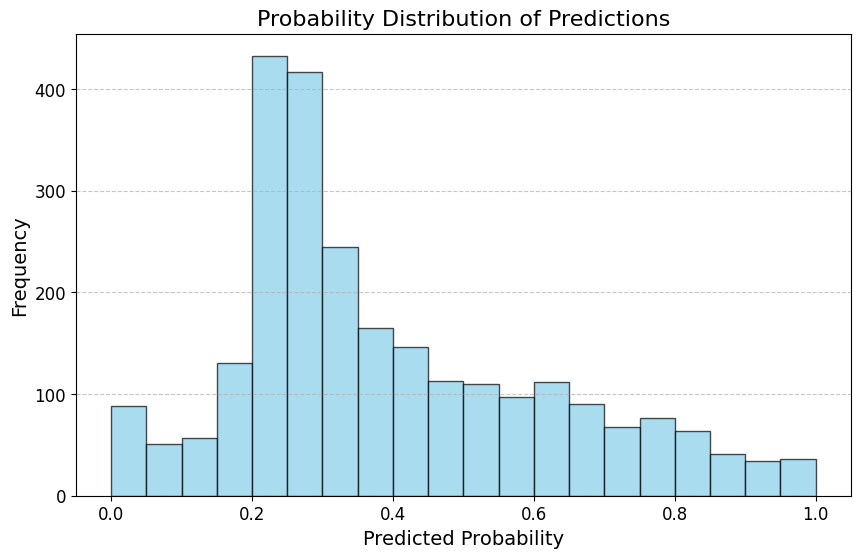

```python
# 預測機率
y_pred_prob = model.predict(X_test)

# 繪製機率分布圖
plt.figure(figsize=(10, 6))
plt.hist(y_pred, bins=20, color='skyblue', edgecolor='black', alpha=0.7)
plt.title('Probability Distribution of Predictions', fontsize=16)
plt.xlabel('Predicted Probability', fontsize=14)
plt.ylabel('Frequency', fontsize=14)
plt.grid(axis='y', linestyle='--', alpha=0.7)
plt.xticks(fontsize=12)
plt.yticks(fontsize=12)
plt.show()
```

每個特徵的重要性可視化(視覺化)。

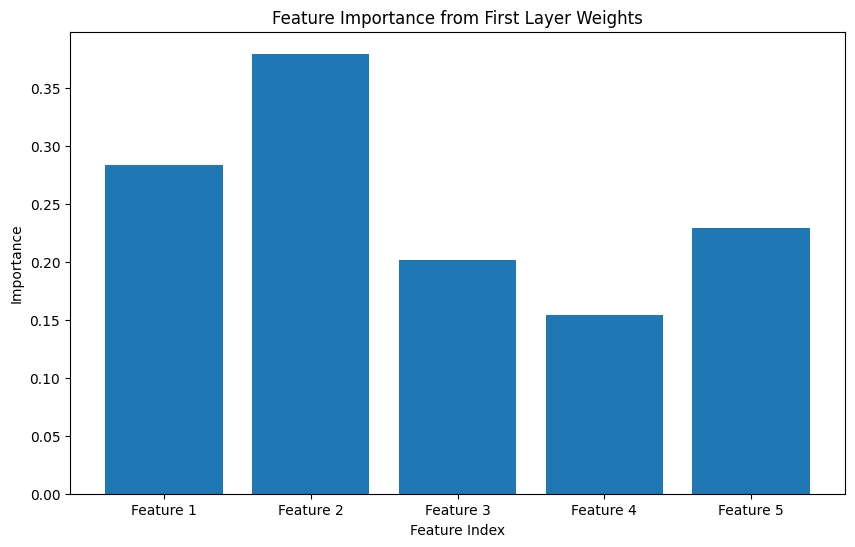

```python
import numpy as np

# 提取第一层的权重
first_layer_weights = model.layers[0].get_weights()[0]  # 第一层的权重
feature_importance = np.mean(np.abs(first_layer_weights), axis=1)

# 可视化特征重要性
plt.figure(figsize=(10, 6))
plt.bar(range(len(feature_importance)), feature_importance, tick_label=[f"Feature {i+1}" for i in range(len(feature_importance))])
plt.xlabel("Feature Index")
plt.ylabel("Importance")
plt.title("Feature Importance from First Layer Weights")
plt.show()
```

# EXAMPLE

這裡我們嘗試先藉由sta/lta來挑選可能的到時，再藉由我們訓練的模型區分P、S波。

```python
# 給一地震事件
# 用 STL/LTA pick 可能的到時
# 進行前處理dmean dtrend taper remove_instrument_response filter_0.1-20HZ
# 用model去pick地震事件到時
#
import numpy as np
from scipy.signal import butter, filtfilt
import matplotlib.pyplot as plt


# 主程式
fs = 100  # 採樣率 100 Hz
file_name = "TW.HWA.10.HLE.*2022*"
file = glob.glob(file_name)
st = read(file[0])
data = st[0].data
# Preprocessing
st[0].detrend(type="demean")
st[0].detrend(type="linear")
# 加窗和濾波
st[0].taper(max_percentage=0.05, type="hann")
nqf=st[0].stats.sampling_rate/2 ###nyquist frequency
pre_filt = [0.005, 0.008 , nqf-2, nqf] ### zero phase filter band
### 把PZ的資料餵給waveform
PZ_file = glob.glob("SAC_PZs_TW_HWA_HLE_10_2018.318.00.00.00.0000_2599.365.23.59.59.99999")
PZ = PZ_file[0]
attach_paz(st[0],PZ)
paz = dict(st[0].stats.paz) ### 從第一個檔案中拿出PZ資料
st[0].simulate(paz_remove=paz,pre_filt=pre_filt)
# waveform.plot()
st[0].taper(0.05, type='hann')
st[0].filter("bandpass", freqmin=0.1, freqmax=20.0)
```

```
TW.HWA.10.HLE | 2022-10-01T00:00:01.290000Z - 2022-10-01T23:59:58.990000Z | 100.0 Hz, 8639771 samples
```

```python
from obspy.signal.trigger import classic_sta_lta, trigger_onset

# 設置 STA/LTA 的參數
sta_window = int(0.1 * st[0].stats.sampling_rate)  # 短時窗
lta_window = int(5.0 * st[0].stats.sampling_rate)  # 長時窗
trigger_on = 2.5  # STA/LTA 超過此值開始觸發
trigger_off = 0.8  # STA/LTA 低於此值結束觸發

# 計算 STA/LTA
trace = st[0]
sta_lta = classic_sta_lta(trace.data, sta_window, lta_window)

# 獲取觸發的時間窗口
onsets = trigger_onset(sta_lta, trigger_on, trigger_off)
print(f"挑選到 {len(onsets)} 個可能的事件到時。")
```

```
挑選到 15012 個可能的事件到時。
```

```python
import glob
from obspy import read
from obspy.signal.trigger import classic_sta_lta, trigger_onset
from obspy.signal.filter import bandpass
import numpy as np
from tensorflow.keras.models import load_model  # 假設模型是用 TensorFlow 訓練的

# 參數設定
fs = 100  # 採樣率 (Hz)
sta_window = 0.5  # STA 窗口長度 (秒)
lta_window = 5.0  # LTA 窗口長度 (秒)
trigger_on = 2.5  # STA/LTA 觸發閾值
trigger_off = 1.0  # STA/LTA 停止閾值
freqmin = 0.1  # 最小頻率
freqmax = 20.0  # 最大頻率

# 讀取地震波資料
file_name = "TW.HWA.10.HLE.*2022*"
file = glob.glob(file_name)
st = read(file[0])
data = st[0].data

# 預處理
st[0].detrend(type="demean")
st[0].detrend(type="linear")

# 加窗和濾波
st[0].taper(max_percentage=0.05, type="hann")
nqf = st[0].stats.sampling_rate / 2  # Nyquist 頻率
pre_filt = [0.005, 0.008, nqf - 2, nqf]  # Zero phase filter band

# 加入儀器響應
PZ_file = glob.glob("SAC_PZs_TW_HWA_HLE_10_2018.318.00.00.00.0000_2599.365.23.59.59.99999")
PZ = PZ_file[0]
from obspy.io.sac import attach_paz
attach_paz(st[0], PZ)
paz = dict(st[0].stats.paz)
st[0].simulate(paz_remove=paz, pre_filt=pre_filt)

# 加窗與濾波
st[0].taper(0.05, type='hann')
st[0].filter("bandpass", freqmin=freqmin, freqmax=freqmax)

# 計算 STA/LTA
sta_samples = int(sta_window * fs)
lta_samples = int(lta_window * fs)
cft = classic_sta_lta(data, sta_samples, lta_samples)

# 設定觸發條件
on_off = trigger_onset(cft, trigger_on, trigger_off)
print(f"可能的到時：{on_off}")

# 載入預訓練模型
# model = load_model("your_model_path.h5")  # 替換成你的模型路徑

# 分析每個觸發段
for onset, offset in on_off:
    segment = data[onset:offset]
    if len(segment) < 100:  # 確保段長足夠
        continue

    # 正規化
    segment = bandpass(segment, freqmin, freqmax, fs, corners=2, zerophase=True)
    segment = (segment - np.mean(segment)) / np.std(segment)

    # 調整為模型輸入格式
    segment = segment[:100]  # 假設模型需要固定長度 (100 點)
    segment = np.expand_dims(segment, axis=0)  # 增加 batch 維度
    segment = np.expand_dims(segment, axis=-1)  # 增加通道維度 (單通道)

    # 模型推論
    prediction = model.predict(segment)
    predicted_class = np.argmax(prediction)  # 假設模型輸出 P/S 概率
    if predicted_class == 0:
        wave_type = "P 波"
    else:
        wave_type = "S 波"
    print(f"觸發段：{onset}-{offset}, 預測為：{wave_type}")
```

```
可能的到時：[]
```

# 測試增加layer

```python
# 最初模型設置
# 訓練分類模型
model = Sequential([
    Dense(128, input_dim=X_train.shape[1], activation='relu'),
    Dense(64, activation='tanh'),
    Dense(32, activation='relu'),
    Dense(1, activation='sigmoid')  # 用 sigmoid 來做二分類
]) #relu', 'tanh', 'sigmoid'
## 訓練模型
# 編譯模型
model.compile(optimizer=Adam(), loss='binary_crossentropy', metrics=['accuracy'])
# 訓練過程
model.fit(X_train, y_train, epochs=100, batch_size=32, validation_data=(X_test, y_test))

# 測試模型
y_pred = model.predict(X_test)
y_pred_label = (y_pred > 0.5).astype(int)

# 計算準確率
accuracy = accuracy_score(y_test, y_pred_label)
print(f"Accuracy: {accuracy * 100:.2f}%")
```

```
93/93 ━━━━━━━━━━━━━━━━━━━━ 6s 10ms/step - accuracy: 0.6212 - loss: 0.6561 - val_accuracy: 0.6371 - val_loss: 0.6547
93/93 ━━━━━━━━━━━━━━━━━━━━ 1s 7ms/step - accuracy: 0.6618 - loss: 0.6275 - val_accuracy: 0.6422 - val_loss: 0.6436
93/93 ━━━━━━━━━━━━━━━━━━━━ 1s 7ms/step - accuracy: 0.6511 - loss: 0.6157 - val_accuracy: 0.6441 - val_loss: 0.6513
93/93 ━━━━━━━━━━━━━━━━━━━━ 1s 4ms/step - accuracy: 0.6891 - loss: 0.5948 - val_accuracy: 0.6414 - val_loss: 0.6551
93/93 ━━━━━━━━━━━━━━━━━━━━ 1s 4ms/step - accuracy: 0.6755 - loss: 0.6060 - val_accuracy: 0.6434 - val_loss: 0.6616
93/93 ━━━━━━━━━━━━━━━━━━━━ 0s 4ms/step - accuracy: 0.6591 - loss: 0.6028 - val_accuracy: 0.6546 - val_loss: 0.6419
93/93 ━━━━━━━━━━━━━━━━━━━━ 1s 5ms/step - accuracy: 0.6813 - loss: 0.5913 - val_accuracy: 0.6503 - val_loss: 0.6711
93/93 ━━━━━━━━━━━━━━━━━━━━ 0s 4ms/step - accuracy: 0.6811 - loss: 0.5913 - val_accuracy: 0.6511 - val_loss: 0.6530
93/93 ━━━━━━━━━━━━━━━━━━━━ 0s 4ms/step - accuracy: 0.6959 - loss: 0.5821 - val_accuracy: 0.6570 - val_loss: 0.6360
93/93 ━━━━━━━━━━━━━━━━━━━━ 1s 4ms/step - accuracy: 0.6743 - loss: 0.5914 - val_accuracy: 0.6371 - val_loss: 0.7012
93/93 ━━━━━━━━━━━━━━━━━━━━ 1s 4ms/step - accuracy: 0.6921 - loss: 0.5722 - val_accuracy: 0.6636 - val_loss: 0.6422
93/93 ━━━━━━━━━━━━━━━━━━━━ 0s 4ms/step - accuracy: 0.6766 - loss: 0.5881 - val_accuracy: 0.6496 - val_loss: 0.6941
93/93 ━━━━━━━━━━━━━━━━━━━━ 1s 4ms/step - accuracy: 0.6864 - loss: 0.5846 - val_accuracy: 0.6674 - val_loss: 0.6439
93/93 ━━━━━━━━━━━━━━━━━━━━ 1s 4ms/step - accuracy: 0.6860 - loss: 0.5901 - val_accuracy: 0.6585 - val_loss: 0.6483
93/93 ━━━━━━━━━━━━━━━━━━━━ 1s 6ms/step - accuracy: 0.7014 - loss: 0.5661 - val_accuracy: 0.6538 - val_loss: 0.6611
93/93 ━━━━━━━━━━━━━━━━━━━━ 1s 8ms/step - accuracy: 0.6891 - loss: 0.5948 - val_accuracy: 0.6589 - val_loss: 0.6873
93/93 ━━━━━━━━━━━━━━━━━━━━ 1s 7ms/step - accuracy: 0.6949 - loss: 0.5824 - val_accuracy: 0.6469 - val_loss: 0.7308
93/93 ━━━━━━━━━━━━━━━━━━━━ 1s 4ms/step - accuracy: 0.6751 - loss: 0.5826 - val_accuracy: 0.6647 - val_loss: 0.6710
93/93 ━━━━━━━━━━━━━━━━━━━━ 1s 4ms/step - accuracy: 0.6922 - loss: 0.5717 - val_accuracy: 0.6601 - val_loss: 0.6770
93/93 ━━━━━━━━━━━━━━━━━━━━ 1s 4ms/step - accuracy: 0.7008 - loss: 0.5762 - val_accuracy: 0.6469 - val_loss: 0.7224
93/93 ━━━━━━━━━━━━━━━━━━━━ 0s 4ms/step - accuracy: 0.6997 - loss: 0.5761 - val_accuracy: 0.6554 - val_loss: 0.6966
93/93 ━━━━━━━━━━━━━━━━━━━━ 0s 4ms/step - accuracy: 0.6960 - loss: 0.5822 - val_accuracy: 0.6484 - val_loss: 0.7468
93/93 ━━━━━━━━━━━━━━━━━━━━ 0s 4ms/step - accuracy: 0.6804 - loss: 0.5834 - val_accuracy: 0.6461 - val_loss: 0.7537
93/93 ━━━━━━━━━━━━━━━━━━━━ 0s 5ms/step - accuracy: 0.6980 - loss: 0.5686 - val_accuracy: 0.6597 - val_loss: 0.6791
93/93 ━━━━━━━━━━━━━━━━━━━━ 1s 4ms/step - accuracy: 0.6794 - loss: 0.5867 - val_accuracy: 0.6519 - val_loss: 0.7129
93/93 ━━━━━━━━━━━━━━━━━━━━ 1s 4ms/step - accuracy: 0.6878 - loss: 0.5678 - val_accuracy: 0.6628 - val_loss: 0.7403
93/93 ━━━━━━━━━━━━━━━━━━━━ 0s 4ms/step - accuracy: 0.7011 - loss: 0.5720 - val_accuracy: 0.6542 - val_loss: 0.7591
93/93 ━━━━━━━━━━━━━━━━━━━━ 0s 4ms/step - accuracy: 0.6990 - loss: 0.5709 - val_accuracy: 0.6469 - val_loss: 0.7894
93/93 ━━━━━━━━━━━━━━━━━━━━ 1s 4ms/step - accuracy: 0.6858 - loss: 0.5858 - val_accuracy: 0.6476 - val_loss: 0.7546
93/93 ━━━━━━━━━━━━━━━━━━━━ 0s 3ms/step - accuracy: 0.6918 - loss: 0.5833 - val_accuracy: 0.6643 - val_loss: 0.6619
93/93 ━━━━━━━━━━━━━━━━━━━━ 1s 3ms/step - accuracy: 0.6835 - loss: 0.5874 - val_accuracy: 0.6542 - val_loss: 0.7102
93/93 ━━━━━━━━━━━━━━━━━━━━ 1s 4ms/step - accuracy: 0.6842 - loss: 0.5823 - val_accuracy: 0.6542 - val_loss: 0.7144
93/93 ━━━━━━━━━━━━━━━━━━━━ 1s 5ms/step - accuracy: 0.7069 - loss: 0.5695 - val_accuracy: 0.6523 - val_loss: 0.7550
93/93 ━━━━━━━━━━━━━━━━━━━━ 1s 7ms/step - accuracy: 0.6966 - loss: 0.5740 - val_accuracy: 0.6550 - val_loss: 0.7601
93/93 ━━━━━━━━━━━━━━━━━━━━ 0s 4ms/step - accuracy: 0.6917 - loss: 0.5769 - val_accuracy: 0.6566 - val_loss: 0.7687
93/93 ━━━━━━━━━━━━━━━━━━━━ 1s 7ms/step - accuracy: 0.6888 - loss: 0.5812 - val_accuracy: 0.6538 - val_loss: 0.7444
93/93 ━━━━━━━━━━━━━━━━━━━━ 1s 7ms/step - accuracy: 0.6832 - loss: 0.5802 - val_accuracy: 0.6309 - val_loss: 0.8951
93/93 ━━━━━━━━━━━━━━━━━━━━ 1s 8ms/step - accuracy: 0.6985 - loss: 0.5793 - val_accuracy: 0.6507 - val_loss: 0.7719
93/93 ━━━━━━━━━━━━━━━━━━━━ 1s 4ms/step - accuracy: 0.7047 - loss: 0.5684 - val_accuracy: 0.6605 - val_loss: 0.7579
93/93 ━━━━━━━━━━━━━━━━━━━━ 1s 4ms/step - accuracy: 0.6803 - loss: 0.5901 - val_accuracy: 0.6593 - val_loss: 0.7482
```

[output cut: 47 more lines]

```
93/93 ━━━━━━━━━━━━━━━━━━━━ 1s 5ms/step - accuracy: 0.7103 - loss: 0.5470 - val_accuracy: 0.6663 - val_loss: 0.8748
93/93 ━━━━━━━━━━━━━━━━━━━━ 1s 7ms/step - accuracy: 0.7086 - loss: 0.5600 - val_accuracy: 0.6651 - val_loss: 1.0003
93/93 ━━━━━━━━━━━━━━━━━━━━ 1s 4ms/step - accuracy: 0.7023 - loss: 0.5603 - val_accuracy: 0.6624 - val_loss: 0.9020
93/93 ━━━━━━━━━━━━━━━━━━━━ 1s 4ms/step - accuracy: 0.7142 - loss: 0.5518 - val_accuracy: 0.6577 - val_loss: 0.9716
93/93 ━━━━━━━━━━━━━━━━━━━━ 1s 4ms/step - accuracy: 0.7161 - loss: 0.5445 - val_accuracy: 0.6639 - val_loss: 1.0267
93/93 ━━━━━━━━━━━━━━━━━━━━ 1s 5ms/step - accuracy: 0.7082 - loss: 0.5571 - val_accuracy: 0.6570 - val_loss: 0.9124
93/93 ━━━━━━━━━━━━━━━━━━━━ 1s 7ms/step - accuracy: 0.7092 - loss: 0.5519 - val_accuracy: 0.6496 - val_loss: 0.9709
93/93 ━━━━━━━━━━━━━━━━━━━━ 2s 10ms/step - accuracy: 0.6974 - loss: 0.5612 - val_accuracy: 0.6566 - val_loss: 0.9604
93/93 ━━━━━━━━━━━━━━━━━━━━ 2s 17ms/step - accuracy: 0.7104 - loss: 0.5503 - val_accuracy: 0.6636 - val_loss: 0.9889
93/93 ━━━━━━━━━━━━━━━━━━━━ 2s 18ms/step - accuracy: 0.7119 - loss: 0.5494 - val_accuracy: 0.6410 - val_loss: 1.0728
93/93 ━━━━━━━━━━━━━━━━━━━━ 2s 13ms/step - accuracy: 0.7250 - loss: 0.5358 - val_accuracy: 0.6554 - val_loss: 0.9261
93/93 ━━━━━━━━━━━━━━━━━━━━ 2s 8ms/step - accuracy: 0.7166 - loss: 0.5509 - val_accuracy: 0.6612 - val_loss: 0.9205
93/93 ━━━━━━━━━━━━━━━━━━━━ 1s 7ms/step - accuracy: 0.7111 - loss: 0.5415 - val_accuracy: 0.6507 - val_loss: 0.9231
81/81 ━━━━━━━━━━━━━━━━━━━━ 0s 4ms/step
Accuracy: 65.07%
```

```python
pip install matplotlib basemap pandas
```

[output not shown]

下面經過課堂中的彙報對程式碼進行了修改，將資料旋轉至地震學中的RTZ方向(可參考:https://blog.seisman.info/coordinate-systems-in-seismology/ )，讓我們可以獲取P波和S波的最大震幅。

此程式碼增加了對資料處理的流程，也增加資料處理的時間，平均一個測站需要3小時長。因此，經常於處理過程中中斷，因此，我們未完成這部分的些改。程式碼已經驗證過並無錯誤，但對模型結果的好壞仍未知。

```python
# discriminate P and S
import os
import glob
import numpy as np
import pandas as pd
from obspy import read
from obspy.io.sac import attach_paz
from obspy.signal.trigger import classic_sta_lta
from obspy.signal.filter import envelope
from obspy import UTCDateTime
from sklearn.preprocessing import StandardScaler
from sklearn.model_selection import train_test_split
from tensorflow.keras.layers import Dropout
from tensorflow.keras.models import Sequential
from tensorflow.keras.layers import Dense
from tensorflow.keras.optimizers import Adam
from sklearn.metrics import accuracy_score
import matplotlib.pyplot as plt
from datetime import datetime, timedelta
from obspy.core.trace import Trace
from obspy import read, Stream
from obspy.geodetics import gps2dist_azimuth

Trace._max_processing_info = 200
# 定義測站與日期
train_sta = ["HWA", "EHP"] # "ENA", "ESL"
test_sta = ["ETM"]
comp = ["HLN", "HLE", "HLZ"]
train_date = ["20180206"]
test_date = ["20180206"]

# 將 YYYYMMDD 轉為儒略日
def date_to_doy(date_str):
    date = datetime.strptime(date_str, "%Y%m%d")  # 解析日期格式
    doy = date.timetuple().tm_yday  # 獲取儒略日
    return f"{date.year}.{doy:03d}"  # 格式化為 YYYY.DDD

# 將日期列表轉換為儒略日列表
train_date_doy = [date_to_doy(d) for d in train_date]
test_date_doy = [date_to_doy(d) for d in test_date]

# 輸出結果
print(f"訓練日期（儒略日格式）: {train_date_doy}")
print(f"測試日期（儒略日格式）: {test_date_doy}")

# 讀取地震事件資訊
event_info = pd.read_csv("evt_PS_0206", sep='\s+', header=None,
                         names=["event_date","event_time", "lat", "lon", "depth", "mag", "Unknown2", "Unknown3", "Unknown4", "event_id"])

station_info = pd.read_csv("sta_PS_20180206", sep='\s+', header=None,
                           names=["station", "latitude", "longitude", "elevation","count"])

# 讀取地震到時檔案
tt_ps_data = []
with open("tt_PS_20180206", "r") as file:
    current_event_id = None
    for line in file:
        line = line.strip()
        if line.startswith("#"):
            current_event_id = int(line.split()[-1])
        else:
            parts = line.split()
            station, travel_time, weight, phase = parts[0], float(parts[1]), int(parts[2]), parts[3]
            tt_ps_data.append([current_event_id, station, travel_time, weight, phase])

tt_ps_df = pd.DataFrame(tt_ps_data, columns=["event_id", "station", "travel_time", "weight", "phase"])


# 特徵提取函數
def extract_features(steam): #, phase):
    features = []
    for trace in steam:
      channel = trace.stats.channel
      data = trace.data
      env = envelope(data)
      sta_lta = classic_sta_lta(data, int(0.1 * trace.stats.sampling_rate), int(1 * trace.stats.sampling_rate))

      if "HLR" in channel: # R comp -> 1
          features.extend([np.max(env), np.mean(env), np.max(sta_lta), np.mean(sta_lta),1])
      elif "HLT" in channel or "HLZ" in channel: # TZ comp -> 2
          features.extend([np.max(env), np.mean(env), np.max(sta_lta), np.mean(sta_lta),2])

      features = [
          np.max(env), np.mean(env),
          np.max(sta_lta), np.mean(sta_lta),
      ]
    return features

def extract_data_with_station_time( stations, dates, selected_phases, event_info, tt_ps_df):
    X, y = [], []

    for station in stations:
        print(f"處理測站: {station}")
        sta_lon = station_info[station_info["station"] == station]["longitude"].values[0]
        sta_lat = station_info[station_info["station"] == station]["latitude"].values[0]
        for date in dates:
            st_files = glob.glob(f"TW.{station}.*{date}*")
            if not st_files:
              print(f"找不到檔案: {station} - {date}")
              continue
            st = Stream()
            for tr_file in st_files:
              tr = read(tr_file)[0]
              st.append(tr)

              PZ_pattern = f"SAC_PZs_TW_{station}_{tr.stats.channel}_*"
              PZ = glob.glob(PZ_pattern)[0]
              attach_paz(tr,PZ)
            print(st)

            stf = st.copy()
            starttime = stf[0].stats.starttime # UTCDateTime
            endtime = stf[0].stats.endtime # UTCDateTime

            for event_id in event_info["event_id"]:
                  event_date = event_info[event_info["event_id"] == event_id]["event_date"].values[0]
                  event_time = event_info[event_info["event_id"] == event_id]["event_time"].values[0]
                  event_mag = event_info[event_info["event_id"] == event_id]["mag"].values[0]
                  event_lon = event_info[event_info["event_id"] == event_id]["lon"].values[0]
                  event_lat = event_info[event_info["event_id"] == event_id]["lat"].values[0]

                  event_time_str = f"{event_date}{str(event_time).zfill(8)[:6]}"
                  event_time_utc = UTCDateTime(event_time_str)

                  if not (starttime <= event_time_utc <= endtime):
                      continue

                  # 不是每個地震事件都能被測站偵測到!
                  matching_rows = tt_ps_df[
                      (tt_ps_df["station"] == station) &
                      (tt_ps_df["phase"].isin(selected_phases)) &
                      (tt_ps_df["event_id"] == event_id)
                  ]

                  dist, az, baz = gps2dist_azimuth(event_lat, event_lon, sta_lat, sta_lon)
                  stf.rotate(method="NE->RT",back_azimuth=baz)

                  stf.detrend(type="demean")
                  stf.detrend(type="linear")
                  stf.taper(max_percentage=0.05, type="hann")

                  nqf=(stf[0].stats.sampling_rate)/2 ###nyquist frequency
                  pre_filt = [0.005, 0.008 , nqf-2, nqf] ### zero phase filter band
                  paz = dict((stf[0].stats.paz))
                  stf.simulate(paz_remove=paz,pre_filt=pre_filt)
                  stf.taper(0.05, type='hann')
                  stf.filter("bandpass", freqmin=0.1, freqmax=20.0)
                  stf_ori = stf.copy()
                  if matching_rows.empty:
                      continue
                  else: # 如果事件被測站偵測到再進行處理
                    start_time = event_time_utc - 10
                    end_time = event_time_utc + 120
                    print(f"event_time_utc: {event_time_utc}")

                    P_arrival = matching_rows[matching_rows["phase"] == "P"].iloc[0]["travel_time"]
                    S_arrival = matching_rows[matching_rows["phase"] == "S"].iloc[0]["travel_time"]

                    try:

                        stf_trimmed = stf_ori.trim(starttime=start_time, endtime=end_time)

                        for phase in selected_phases:
                            if phase == "P":
                              # trim stf_processed from P_arrival to P_arrival+5
                              stf_trimmed_P = stf_trimmed.trim(start_time + 5 + P_arrival, start_time + 10 + P_arrival + 5)
                              features = extract_features(stf_trimmed_P) # , phase)
                              phase_label = 0

                            else:
                              # trim stf_processed from S_arrival to S_arrival+15
                              stf_trimmed_S = stf_trimmed.trim(start_time + 5 + S_arrival, start_time + 10 + S_arrival + 15)
                              features = extract_features(stf_trimmed_S) # , phase)
                              phase_label = 1

                            X.append(features + [event_mag])
                            y.append(phase_label)
                    except Exception as e:
                        print(f"波形處理失敗: {e}")
                        continue
    return np.array(X), np.array(y)

# 提取數據與標籤
selected_phases = ["P", "S"]

X_train, y_train = extract_data_with_station_time(train_sta, train_date_doy, selected_phases, event_info, tt_ps_df)
X_test, y_test = extract_data_with_station_time(test_sta, train_date_doy, selected_phases, event_info, tt_ps_df)

# 標準化數據
scaler = StandardScaler()
X_train = scaler.fit_transform(X_train)
X_test = scaler.transform(X_test)
```

```
訓練日期（儒略日格式）: ['2018.037']
測試日期（儒略日格式）: ['2018.037']
處理測站: HWA
3 Trace(s) in Stream:
TW.HWA.10.HLN | 2018-02-06T00:00:00.000000Z - 2018-02-06T23:59:58.990000Z | 100.0 Hz, 8639900 samples
TW.HWA.10.HLZ | 2018-02-06T00:00:00.000000Z - 2018-02-06T23:59:58.990000Z | 100.0 Hz, 8639900 samples
TW.HWA.10.HLE | 2018-02-06T00:00:00.000000Z - 2018-02-06T23:59:58.990000Z | 100.0 Hz, 8639900 samples
event_time_utc: 2018-02-06T05:09:14.000000Z
event_time_utc: 2018-02-06T08:26:39.000000Z
event_time_utc: 2018-02-06T09:00:43.000000Z
event_time_utc: 2018-02-06T09:12:58.000000Z
event_time_utc: 2018-02-06T09:50:37.000000Z
```

```
event_time_utc: 2018-02-06T12:23:29.000000Z
event_time_utc: 2018-02-06T15:52:09.000000Z
event_time_utc: 2018-02-06T15:53:31.000000Z
event_time_utc: 2018-02-06T15:58:41.000000Z
event_time_utc: 2018-02-06T16:03:34.000000Z
event_time_utc: 2018-02-06T16:04:20.000000Z
event_time_utc: 2018-02-06T16:06:29.000000Z
event_time_utc: 2018-02-06T16:09:03.000000Z
event_time_utc: 2018-02-06T16:11:27.000000Z
event_time_utc: 2018-02-06T16:11:36.000000Z
event_time_utc: 2018-02-06T16:13:47.000000Z
event_time_utc: 2018-02-06T16:16:31.000000Z
event_time_utc: 2018-02-06T16:17:57.000000Z
event_time_utc: 2018-02-06T16:18:41.000000Z
event_time_utc: 2018-02-06T16:25:53.000000Z
event_time_utc: 2018-02-06T16:26:01.000000Z
event_time_utc: 2018-02-06T16:34:56.000000Z
event_time_utc: 2018-02-06T16:35:46.000000Z
event_time_utc: 2018-02-06T16:38:24.000000Z
event_time_utc: 2018-02-06T16:46:15.000000Z
event_time_utc: 2018-02-06T16:52:56.000000Z
event_time_utc: 2018-02-06T16:53:37.000000Z
event_time_utc: 2018-02-06T16:54:22.000000Z
event_time_utc: 2018-02-06T16:56:54.000000Z
event_time_utc: 2018-02-06T16:57:31.000000Z
event_time_utc: 2018-02-06T16:57:55.000000Z
event_time_utc: 2018-02-06T16:59:11.000000Z
event_time_utc: 2018-02-06T17:01:56.000000Z
event_time_utc: 2018-02-06T17:09:12.000000Z
event_time_utc: 2018-02-06T17:09:30.000000Z
event_time_utc: 2018-02-06T17:12:54.000000Z
event_time_utc: 2018-02-06T17:17:59.000000Z
event_time_utc: 2018-02-06T17:45:56.000000Z
event_time_utc: 2018-02-06T17:47:00.000000Z
event_time_utc: 2018-02-06T17:49:03.000000Z
event_time_utc: 2018-02-06T17:49:19.000000Z
event_time_utc: 2018-02-06T17:50:51.000000Z
event_time_utc: 2018-02-06T17:51:35.000000Z
event_time_utc: 2018-02-06T17:54:32.000000Z
event_time_utc: 2018-02-06T18:09:23.000000Z
```

[output cut: 87 more lines]

```
event_time_utc: 2018-02-06T11:12:59.000000Z
event_time_utc: 2018-02-06T12:23:29.000000Z
event_time_utc: 2018-02-06T12:25:44.000000Z
event_time_utc: 2018-02-06T12:26:21.000000Z
event_time_utc: 2018-02-06T13:36:45.000000Z
event_time_utc: 2018-02-06T13:53:33.000000Z
event_time_utc: 2018-02-06T14:00:04.000000Z
event_time_utc: 2018-02-06T14:46:03.000000Z
event_time_utc: 2018-02-06T15:23:27.000000Z
event_time_utc: 2018-02-06T15:50:41.000000Z
event_time_utc: 2018-02-06T15:56:50.000000Z
event_time_utc: 2018-02-06T15:59:19.000000Z
event_time_utc: 2018-02-06T15:59:44.000000Z
event_time_utc: 2018-02-06T16:17:57.000000Z
event_time_utc: 2018-02-06T16:35:46.000000Z
```

```python
# 最初模型設置
# 訓練分類模型
model = Sequential([
    Dense(64, input_dim=X_train.shape[1], activation='relu'),
    Dense(64, activation='relu'),
    Dense(1, activation='sigmoid')  # 用 sigmoid 來做二分類
])
## 訓練模型
# 編譯模型
model.compile(optimizer=Adam(), loss='binary_crossentropy', metrics=['accuracy'])
# 訓練過程
model.fit(X_train, y_train, epochs=100, batch_size=32, validation_data=(X_test, y_test))

# 測試模型
y_pred = model.predict(X_test)
y_pred_label = (y_pred > 0.5).astype(int)

# 計算準確率
accuracy = accuracy_score(y_test, y_pred_label)
print(f"Accuracy: {accuracy * 100:.2f}%")


from sklearn.metrics import mean_squared_error, r2_score

# 計算訓練集的預測
y_train_pred = model.predict(X_train)
y_train_pred_label = (y_train_pred > 0.5).astype(int)

# 訓練集指標
train_rmse = np.sqrt(mean_squared_error(y_train, y_train_pred))
train_r2 = r2_score(y_train, y_train_pred)

# 測試集指標
test_rmse = np.sqrt(mean_squared_error(y_test, y_pred))
test_r2 = r2_score(y_test, y_pred)

# 輸出結果
print(f"Training RMSE: {train_rmse:.4f}")
print(f"Training R²: {train_r2:.4f}")
print(f"Testing RMSE: {test_rmse:.4f}")
print(f"Testing R²: {test_r2:.4f}")

# 預測機率
y_pred_prob = model.predict(X_test)

# 繪製機率分布圖
plt.figure(figsize=(10, 6))
plt.hist(y_pred, bins=20, color='skyblue', edgecolor='black', alpha=0.7)
plt.title('Probability Distribution of Predictions', fontsize=16)
plt.xlabel('Predicted Probability', fontsize=14)
plt.ylabel('Frequency', fontsize=14)
plt.grid(axis='y', linestyle='--', alpha=0.7)
plt.xticks(fontsize=12)
plt.yticks(fontsize=12)
plt.show()


import numpy as np

# 提取第一层的权重
first_layer_weights = model.layers[0].get_weights()[0]  # 第一层的权重
feature_importance = np.mean(np.abs(first_layer_weights), axis=1)

# 可视化特征重要性
plt.figure(figsize=(10, 6))
plt.bar(range(len(feature_importance)), feature_importance, tick_label=[f"Feature {i+1}" for i in range(len(feature_importance))])
plt.xlabel("Feature Index")
plt.ylabel("Importance")
plt.title("Feature Importance from First Layer Weights")
plt.show()
```

```python
from google.colab import drive
drive.mount('/content/drive')
```

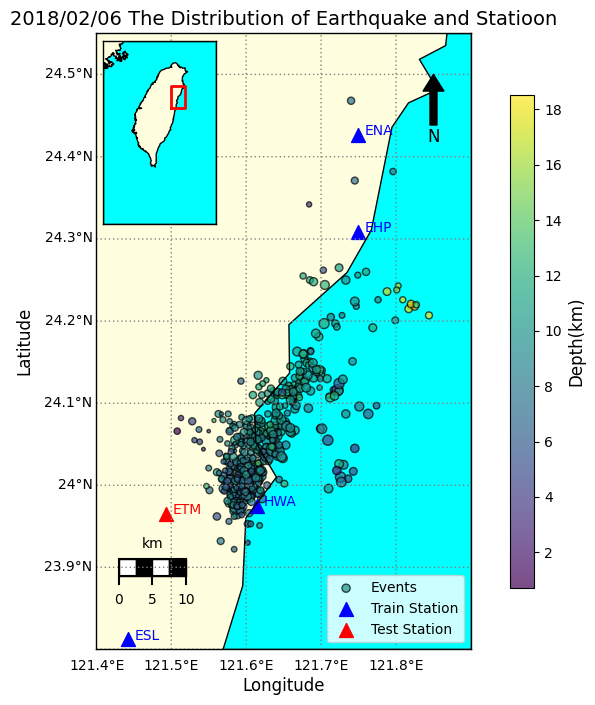

```python
import pandas as pd
import numpy as np
import matplotlib.pyplot as plt
from mpl_toolkits.basemap import Basemap
from mpl_toolkits.axes_grid1.inset_locator import inset_axes

file_path = "/content/drive/MyDrive/Colab Notebooks/data/evt_PS_20180206.csv"
file_path_2 = "/content/drive/MyDrive/Colab Notebooks/data/sta_PS_20180206.csv"

# 讀取地震資料
data = pd.read_csv(file_path)
data2 = pd.read_csv(file_path_2)

# 提取經緯度和深度
lats = data['lat']
lons = data['lon']
depths = data['depth']
magnitudes = data['magnitude']

# 主地圖
#plt.figure(figsize=(10, 8))
fig, ax = plt.subplots(figsize=(10, 8))
m = Basemap(projection='merc',
            llcrnrlat=23.8, urcrnrlat=24.55,  # 台灣經緯度範圍
            llcrnrlon=121.4, urcrnrlon=121.9,
            resolution='i')

# 繪製地圖邊界和填充顏色
m.drawcoastlines()
m.drawcountries()
m.fillcontinents(color='lightyellow', lake_color='aqua')
m.drawmapboundary(fill_color='aqua')

# 加入經緯線
parallels = np.arange(23.8, 24.55, 0.1)  # 緯線範圍 (y 軸)
meridians = np.arange(121.4, 121.9, 0.1)  # 經線範圍 (x 軸)

m.drawparallels(parallels, labels=[1, 0, 0, 0], fontsize=10, color='gray', dashes=[1, 2])
m.drawmeridians(meridians, labels=[0, 0, 0, 1], fontsize=10, color='gray', dashes=[1, 2])
#m.drawparallels(range(23, 26, 1), labels=[1, 0, 0, 0], fontsize=10, color='gray', dashes=[1, 2])
#m.drawmeridians(range(121, 123, 1), labels=[0, 0, 0, 1], fontsize=10, color='gray', dashes=[1, 2])

# 將經緯度轉換為地圖上的點
x, y = m(lons.values, lats.values)

# 根據地震深度繪製散點圖，顏色表示深度
sc = m.scatter(x, y, c=depths, cmap='viridis', s=magnitudes*10, edgecolor='k', alpha=0.7, label="Events")

# 加入顏色條
cb = plt.colorbar(sc, orientation='vertical', shrink=0.8, pad=0.05)
cb.set_label('Depth(km)', fontsize=12)

# 繪製地震站
for i, row in data2.iterrows():
    x_sta, y_sta = m(row['Lon_sta'], row['Lat_sta'])
    if row['Station'] == "ETM":  # Test station
        m.scatter(x_sta, y_sta, marker='^', color='red', s=100, label="Test Station" if "Test Station" not in ax.get_legend_handles_labels()[1] else "")
        plt.text(x_sta + 1000, y_sta, row['Station'], fontsize=10, color='red')  # 加測站名稱
    else:  # Train stations
        m.scatter(x_sta, y_sta, marker='^', color='blue', s=100, label="Train Station" if "Train Station" not in ax.get_legend_handles_labels()[1] else "")
        plt.text(x_sta + 1000, y_sta, row['Station'], fontsize=10, color='blue')  # 加測站名稱

# 加入圖例
plt.legend(loc='lower right', fontsize=10)

# 加入標題
plt.title('2018/02/06 The Distribution of Earthquake and Statioon', fontsize=14)
plt.xlabel('Longitude', fontsize=12,labelpad=20)
plt.ylabel('Latitude', fontsize=12,labelpad=45)

# 加入指北針
x_arrow, y_arrow = m(121.85, 24.5)  # 指北針的位置
plt.annotate('N', xy=(x_arrow, y_arrow), xytext=(x_arrow, y_arrow - 10000),
             arrowprops=dict(facecolor='black', width=5, headwidth=15),
             ha='center', fontsize=12, color='black')

# 加入比例尺
m.drawmapscale(121.475, 23.9, 121.7, 23.9, 10, barstyle='fancy', units='km',
               fontsize=10, yoffset=2500, labelstyle='simple')

# 加入內嵌台灣全域地圖
#ax_inset = inset_axes(plt.gca(), width="30%", height="30%", loc='upper left')
ax_inset = inset_axes(ax, width="30%", height="30%", loc='upper left')
m_inset = Basemap(projection='merc',
                  llcrnrlat=20, urcrnrlat=26,  # 台灣大範圍經緯度
                  llcrnrlon=119, urcrnrlon=123,
                  resolution='i',
                  ax=ax_inset)

# 繪製內嵌地圖邊界和填充顏色
m_inset.drawcoastlines()
m_inset.fillcontinents(color='lightyellow', lake_color='aqua')
m_inset.drawmapboundary(fill_color='aqua')

# 在內嵌地圖上圈出研究區域
x0, y0 = m_inset([121.4, 121.9], [23.85, 24.55])
m_inset.plot([x0[0], x0[0], x0[1], x0[1], x0[0]],
             [y0[0], y0[1], y0[1], y0[0], y0[0]],
             color='red', linewidth=2)

# 顯示地圖
plt.show()
```

# Reference

Central Weather Administration. (2012). Central Weather Administration Seismographic Network [Data set]. International Federation of Digital Seismograph Networks. https://doi.org/10.7914/SN/T5

Mildon, Z.K., Roberts, G.P., Faure Walker, J.P. et al. Surface faulting earthquake clustering controlled by fault and shear-zone interactions. Nat Commun 13, 7126 (2022). https://doi.org/10.1038/s41467-022-34821-5

Sun, WF., Pan, SY., Huang, CM. et al. Deep learning-based earthquake catalog reveals the seismogenic structures of the 2022 MW 6.9 Chihshang earthquake sequence. Terr Atmos Ocean Sci 35, 5 (2024). https://doi.org/10.1007/s44195-024-00063-9